# DAT 301 Project 1

Dain Lee

2024-02-05

## Introduction

- Happiness holds significance globally, and the World Happiness Report offers insights into worldwide well-being dynamics.
- The data set encompasses happiness scores and associated factors for 137 countries.
- **Question: What factors contribute to disparities in happiness levels across countries, and how can we address these disparities effectively?**

## Loading the Data

```r
happiness_data <- read.csv("WHR2023.csv")

# Define original and new column names
original_names <- c("Country name", "Ladder_score", "Standard_error", "Upper_whisker",
                    "Lower_whisker", "Logged_GDP_per_capita", "Social_support",
                    "Healthy_life_expectancy", "Freedom_to_make_life_choices",
                    "Generosity", "Perceptions_of_corruption", "Ladder_score_in_Dystopia",
                    "Explained_by_Log_GDP_per_capita", "Explained_by_Social_support",
                    "Explained_by_Healthy_life_expectancy",
                    "Explained_by_Freedom_to_make_life_choices", "Explained_by_Generosity",
                    "Explained_by_Perceptions_of_corruption", "Dystopia_residual")

new_names <- c("Country", "Score", "Error", "Upper_Whisker", "Lower_Whisker",
                "GDP_per_Capita", "Social_Support", "Life_Expectancy",
                "Freedom", "Generosity", "Corruption_Perception",
                "Dystopia_Score", "Explained_GDP",
                "Explained_Social_Support", "Explained_Life_Expectancy",
                "Explained_Freedom", "Explained_Generosity",
                "Explained_Corruption_Perception", "Dystopia_Residual")

names(happiness_data) <- new_names
```

## Top 10 Happiest Countries

```r
top_10_happiest_countries <- happiness_data[order(happiness_data$Score, decreasing = TRUE), ][1:10, c("Country", "Score")]

# Calculate mean GDP per capita, social support, and life expectancy for the top 10 happiest countries
mean_gdp <- sapply(top_10_happiest_countries$Country, function(country) {
  mean(happiness_data$GDP_per_Capita[happiness_data$Country == country])
})

mean_social_support <- sapply(top_10_happiest_countries$Country, function(country) {
  mean(happiness_data$Social_Support[happiness_data$Country == country])
})

mean_life_expectancy <- sapply(top_10_happiest_countries$Country, function(country) {
  mean(happiness_data$Life_Expectancy[happiness_data$Country == country])
})

# Add mean GDP per capita, social support, and life expectancy to the table
top_10_happiest_countries$Mean_GDP_per_Capita <- mean_gdp
top_10_happiest_countries$Mean_Social_Support <- mean_social_support
top_10_happiest_countries$Mean_Life_Expectancy <- mean_life_expectancy

# Print the updated table
print("Top 10 Happiest Countries with Mean GDP per Capita, Social Support, and Life Expectancy:")
```

```
## [1] "Top 10 Happiest Countries with Mean GDP per Capita, Social Support, and Life Expectancy:"
```

```r
print(top_10_happiest_countries)
```

```
##        Country Score Mean_GDP_per_Capita Mean_Social_Support
## 1      Finland 7.804              10.792               0.969
## 2      Denmark 7.586              10.962               0.954
## 3      Iceland 7.530              10.896               0.983
## 4       Israel 7.473              10.639               0.943
## 5  Netherlands 7.403              10.942               0.930
## 6       Sweden 7.395              10.883               0.939
## 7       Norway 7.315              11.088               0.943
## 8  Switzerland 7.240              11.164               0.920
## 9   Luxembourg 7.228              11.660               0.879
## 10 New Zealand 7.123              10.662               0.952
##    Mean_Life_Expectancy
## 1                71.150
## 2                71.250
## 3                72.050
## 4                72.697
## 5                71.550
## 6                72.150
## 7                71.500
## 8                72.900
## 9                71.675
## 10               70.350
```

We identify and analyze the top 10 happiest countries, computing mean factors to understand their association with happiness.

## Exploring Well-being: Analysis of Key Variables

```r
library(ggplot2)

# Summary statistics for key variables
summary(happiness_data[, c("Score", "GDP_per_Capita", "Social_Support", "Life_Expectancy")])
```

```
##      Score       GDP_per_Capita   Social_Support   Life_Expectancy
##  Min.   :1.859   Min.   : 5.527   Min.   :0.3410   Min.   :51.53
##  1st Qu.:4.724   1st Qu.: 8.591   1st Qu.:0.7220   1st Qu.:60.65
##  Median :5.684   Median : 9.567   Median :0.8270   Median :65.84
##  Mean   :5.540   Mean   : 9.450   Mean   :0.7991   Mean   :64.97
##  3rd Qu.:6.334   3rd Qu.:10.540   3rd Qu.:0.8960   3rd Qu.:69.41
##  Max.   :7.804   Max.   :11.660   Max.   :0.9830   Max.   :77.28
##                                                    NA's   :1
```

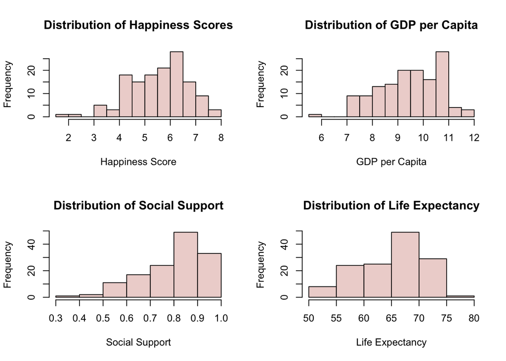

```r
# Histograms for key variables
par(mfrow = c(2, 2))  # Set up a 2x2 grid for plots
hist(happiness_data$Score, main = "Distribution of Happiness Scores", xlab = "Happiness Score", col = "mistyrose2")
hist(happiness_data$GDP_per_Capita, main = "Distribution of GDP per Capita", xlab = "GDP per Capita", col = "mistyrose2")
hist(happiness_data$Social_Support, main = "Distribution of Social Support", xlab = "Social Support", col = "mistyrose2")
hist(happiness_data$Life_Expectancy, main = "Distribution of Life Expectancy", xlab = "Life Expectancy", col = "mistyrose2")
```

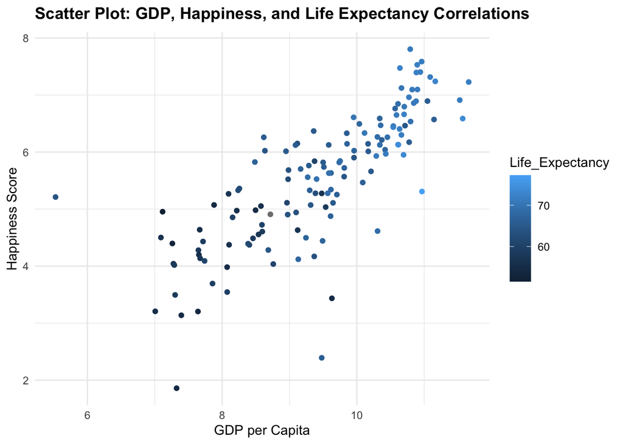

```r
# Scatter Plot matrix for key variables
ggplot(happiness_data, aes(x = GDP_per_Capita, y = Score)) +
  geom_point(aes(color = Life_Expectancy)) +
  labs(title = expression(paste(bold("Scatter Plot: GDP, Happiness, and Life Expectancy Correlations"))),
       x = "GDP per Capita",
       y = "Happiness Score") +
  theme_minimal()
```

## Correlation Analysis: Factors Associated with Happiness Scores

```r
correlation_matrix <- cor(happiness_data[c("Score", "GDP_per_Capita", "Social_Support", "Life_Expectancy")])

print(correlation_matrix)
```

```
##                     Score GDP_per_Capita Social_Support Life_Expectancy
## Score           1.0000000      0.7843673      0.8345317              NA
## GDP_per_Capita  0.7843673      1.0000000      0.7380688              NA
## Social_Support  0.8345317      0.7380688      1.0000000              NA
## Life_Expectancy        NA             NA             NA               1
```

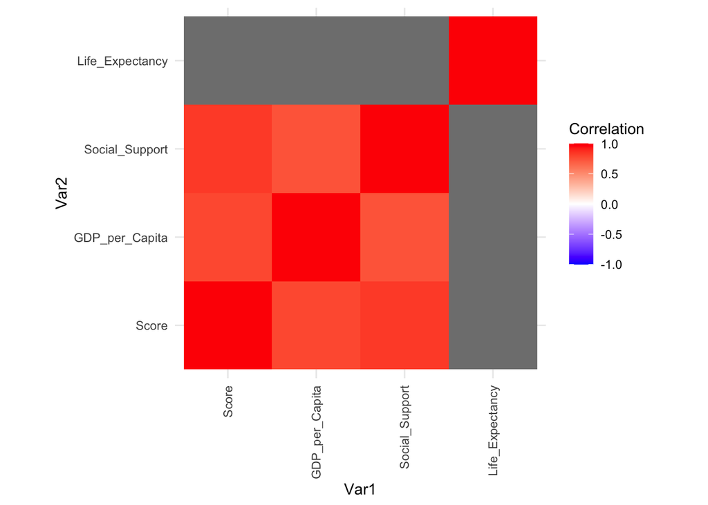

```r
# Visualize correlation matrix using heatmap
library(ggplot2)
library(reshape2)

melted_correlation <- melt(correlation_matrix)
ggplot(data = melted_correlation, aes(x = Var1, y = Var2, fill = value)) +
  geom_tile() +
  scale_fill_gradient2(low = "blue", high = "red", mid = "white",
                       midpoint = 0, limit = c(-1,1), space = "Lab",
                       name="Correlation") +
  theme_minimal() +
  theme(axis.text.x = element_text(angle = 90, vjust = 0.5, hjust=1)) +
  coord_fixed()
```

The correlation heatmap illustrates relationships between variables associated with happiness scores, indicating positive or negative associations. We observe a strong positive correlation between GDP per Capita and Happiness Scores, underscoring the role of economic factors in well-being. Additionally, Social Support shows a positive correlation with Happiness Scores, emphasizing the importance of social connections. This analysis sheds light on factors influencing happiness disparities.

## Regional Disparities in Happiness

```r
library(dplyr)
```

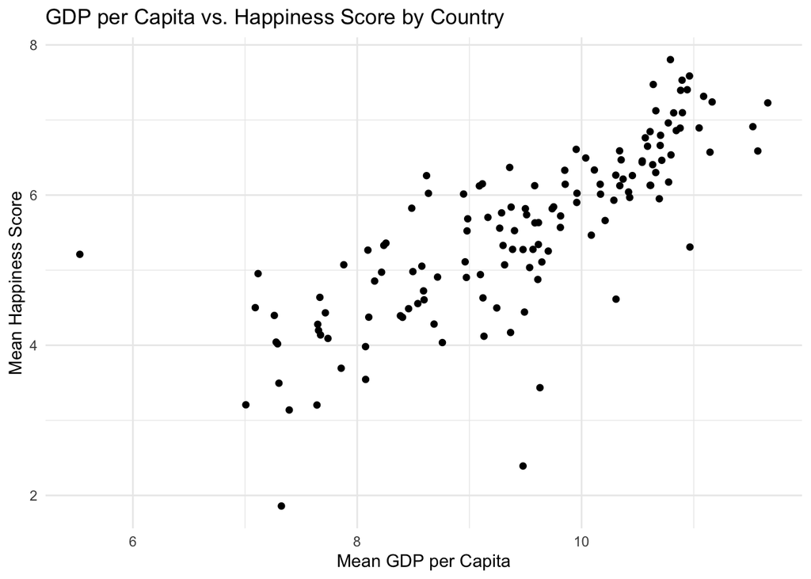

```r
country_summary <- happiness_data %>%
  group_by(Country) %>%
  summarise(
    Mean_Happiness_Score = mean(Score),
    Mean_GDP_per_Capita = mean(GDP_per_Capita),
    Mean_Social_Support = mean(Social_Support),
    Mean_Life_Expectancy = mean(Life_Expectancy)
  )

# Visualize happiness indicators among countries
# Scatter plot comparing GDP per capita and happiness scores by country
ggplot(country_summary, aes(x = Mean_GDP_per_Capita, y = Mean_Happiness_Score)) +
  geom_point() +
  labs(title = "GDP per Capita vs. Happiness Score by Country",
       x = "Mean GDP per Capita",
       y = "Mean Happiness Score") +
  theme_minimal()
```

In this section, we delve into happiness indicators by country, calculating mean values for GDP per capita and happiness scores. Through statistical aggregation and visualizations, we uncover insights into well-being variations across countries, shedding light on global happiness dynamics and socio-economic conditions.

## Identifying Outliers and Anomalies

```r
# Define outlier detection function
detect_outliers <- function(data, variable) {
  q1 <- quantile(data[[variable]], 0.25)
  q3 <- quantile(data[[variable]], 0.75)
  iqr <- q3 - q1
  lower_bound <- q1 - 1.5 * iqr
  upper_bound <- q3 + 1.5 * iqr
  outliers <- data[data[[variable]] < lower_bound | data[[variable]] > upper_bound, ]
  return(outliers)
}

# Detect outliers in happiness scores
happiness_outliers <- detect_outliers(happiness_data, "Score")

# Investigate countries with exceptionally high or low happiness scores
print("Countries with exceptionally high or low happiness scores:")
```

```
## [1] "Countries with exceptionally high or low happiness scores:"
```

```r
print(happiness_outliers)
```

```
##         Country Score Error Upper_Whisker Lower_Whisker GDP_per_Capita
## 137 Afghanistan 1.859 0.033         1.923         1.795          7.324
##     Social_Support Life_Expectancy Freedom Generosity Corruption_Perception
## 137          0.341          54.712   0.382     -0.081                 0.847
##     Dystopia_Score Explained_GDP Explained_Social_Support
## 137          1.778         0.645                        0
##     Explained_Life_Expectancy Explained_Freedom Explained_Generosity
## 137                     0.087                 0                0.093
##     Explained_Corruption_Perception Dystopia_Residual
## 137                           0.059             0.976
```

## Conclusion

Our analysis of the World Happiness Report data across 137 countries reveals crucial insights into global well-being dynamics. Top-ranking nations like Finland and Denmark exhibit high happiness scores, often correlated with robust GDP per capita, social support, and life expectancy.

Key variables such as **happiness score**, **GDP per capita**, and **social support** exhibit meaningful correlations, emphasizing the significance of *economic and social factors* in happiness levels. Regional disparities, exemplified by outliers like Afghanistan, underscore the need for targeted interventions to address underlying socio-economic challenges.

In conclusion, prioritizing equitable economic growth, robust social support structures, and accessible healthcare systems can help governments and policymakers mitigate happiness disparities and foster greater well-being worldwide.

## Possible Policy implications and Recommendations

- **Inclusive Growth**: Prioritize inclusive economic policies to reduce income inequality and enhance overall well-being through education, job creation, and entrepreneurship.
- **Social Support Networks**: Strengthen healthcare, social services, and community programs to build resilience and foster happiness amid adverse circumstances.
- **Transparent Governance**: Establish transparent governance and anti-corruption measures to foster public trust and create environments conducive to happiness and prosperity.

## Future Research Directions:

1. **Longitudinal Studies:** Conduct longitudinal studies to track changes in happiness indicators over time and understand the long-term impact of policy interventions and socio-economic trends.
2. **Cross-Cultural Analysis:** Explore cross-cultural variations in happiness determinants and examine how cultural factors influence subjective well-being across diverse populations.
3. **Technology and Well-being:** Investigate the role of technology in shaping happiness levels, including its impact on social interactions, mental health, and work-life balance.